# Week 4 Complex Model

```python
# Import libraries for EDA:
import pandas as pd
import matplotlib as plt
import seaborn as sns
import numpy as np
```

```python
# Import file(s) from main folder to start looking at columns in each file:

df_details = pd.read_csv(r'/Users/ben/CSUF/Course 5, Capstone/MAL Anime Top 10000 Details.csv')
df_writtenreviews = pd.read_csv(r'/Users/ben/CSUF/Course 5, Capstone/MAL Anime Reviews 85k.csv')
df_UserRecs = pd.read_csv(r'/Users/ben/CSUF/Course 5, Capstone/MAL Anime Recommendations 45k.csv')
```

```python
df_details.head()
```

|  | Anime Title | MAL Url | English | Japanese | Type | Episodes | Status | Aired | Premiered | Broadcast | ... | Source | Genres | Duration | Rating | Score | Ranking | Popularity | Members | Favorites | Summary |
| --- | --- | --- | --- | --- | --- | --- | --- | --- | --- | --- | --- | --- | --- | --- | --- | --- | --- | --- | --- | --- | --- |
| 0 | Fullmetal Alchemist: Brotherhood | https://myanimelist.net/anime/5114/Fullmetal_A... | Fullmetal Alchemist: Brotherhood | 鋼の錬金術師 FULLMETAL ALCHEMIST | TV | 64 | Finished Airing | Apr 5, 2009 to Jul 4, 2010 | Spring 2009 | Sundays at 17:00 (JST) | ... | Manga | Action, Military, Adventure, Comedy, Drama, Ma... | 24 min. per ep. | R - 17+ (violence & profanity) | 9.22 | 1 | 4 | 2025613 | 167812 | "In order for something to be obtained, someth... |
| 1 | Steins;Gate | https://myanimelist.net/anime/9253/Steins_Gate | Steins;Gate | STEINS;GATE | TV | 24 | Finished Airing | Apr 6, 2011 to Sep 14, 2011 | Spring 2011 | Wednesdays at 02:05 (JST) | ... | Visual novel | Thriller, Sci-Fi | 24 min. per ep. | PG-13 - Teens 13 or older | 9.12 | 2 | 8 | 1636151 | 139909 | The self-proclaimed mad scientist Rintarou Oka... |
| 2 | Gintama° | https://myanimelist.net/anime/28977/Gintama° | Gintama Season 4 | 銀魂° | TV | 51 | Finished Airing | Apr 8, 2015 to Mar 30, 2016 | Spring 2015 | Wednesdays at 18:00 (JST) | ... | Manga | Action, Comedy, Historical, Parody, Samurai, S... | 24 min. per ep. | PG-13 - Teens 13 or older | 9.11 | 3 | 330 | 363879 | 10353 | Gintoki, Shinpachi, and Kagura return as the f... |
| 3 | Hunter x Hunter (2011) | https://myanimelist.net/anime/11061/Hunter_x_H... | Hunter x Hunter | HUNTER×HUNTER（ハンター×ハンター） | TV | 148 | Finished Airing | Oct 2, 2011 to Sep 24, 2014 | Fall 2011 | Sundays at 10:55 (JST) | ... | Manga | Action, Adventure, Fantasy, Shounen, Super Power | 23 min. per ep. | PG-13 - Teens 13 or older | 9.11 | 4 | 14 | 1459320 | 130492 | Hunter x Hunter is set in a world where Hunter... |
| 4 | Ginga Eiyuu Densetsu | https://myanimelist.net/anime/820/Ginga_Eiyuu_... | Legend of the Galactic Heroes | 銀河英雄伝説 | OVA | 110 | Finished Airing | Jan 8, 1988 to Mar 17, 1997 | NaN | NaN | ... | Novel | Military, Sci-Fi, Space, Drama | 26 min. per ep. | R - 17+ (violence & profanity) | 9.10 | 5 | 629 | 212162 | 13100 | The 150-year-long stalemate between the two in... |

5 rows × 23 columns

This file has the most useful columns, as it includes score of average viewer ratings as 'score', also 'ranking', and 'popularity'..

```python
df_details.info()
```

```
<class 'pandas.core.frame.DataFrame'>
RangeIndex: 10000 entries, 0 to 9999
Data columns (total 23 columns):
 #   Column       Non-Null Count  Dtype
---  ------       --------------  -----
 0   Anime Title  10000 non-null  object
 1   MAL Url      10000 non-null  object
 2   English      4983 non-null   object
 3   Japanese     9993 non-null   object
 4   Type         10000 non-null  object
 5   Episodes     10000 non-null  object
 6   Status       10000 non-null  object
 7   Aired        10000 non-null  object
 8   Premiered    3681 non-null   object
 9   Broadcast    3681 non-null   object
 10  Producers    6261 non-null   object
 11  Licensors    3617 non-null   object
 12  Studios      8030 non-null   object
 13  Source       10000 non-null  object
 14  Genres       10000 non-null  object
 15  Duration     10000 non-null  object
 16  Rating       10000 non-null  object
 17  Score        10000 non-null  float64
 18  Ranking      10000 non-null  int64
 19  Popularity   10000 non-null  int64
 20  Members      10000 non-null  int64
 21  Favorites    10000 non-null  int64
 22  Summary      10000 non-null  object
dtypes: float64(1), int64(4), object(18)
memory usage: 1.8+ MB
```

It looks like we will have some missing values for the English and Japanese title columns. We will also miss some values in the 'Premiered', 'Broadcast', 'Producers','Licensors', and 'Studios' columns. I think I can remove most of these columns as there is other valuable information that I can use here (i.e. 'Anime Title', 'Aired'). I might want to keep 'Producers' and 'Studios' as a relevant columns, so I will try to revisit missing values here.

```python
df_writtenreviews.head(50)
```

|  | Anime Rank | Anime Title | Anime URL | Username | Review Date | Episodes Watched | Review Likes | Overall Rating | Story Rating | Animation Rating | Sound Rating | Character Rating | Enjoyment Rating | Review |
| --- | --- | --- | --- | --- | --- | --- | --- | --- | --- | --- | --- | --- | --- | --- |
| 0 | 1 | Fullmetal Alchemist: Brotherhood | https://myanimelist.net/anime/5114/Fullmetal_A... | tazillo | Jan 25, 2010 | 64 of 64 episodes seen | 3464 | 10 | 10 | 9 | 9 | 10 | 10 | First of all, I have seen the original FMA and... |
| 1 | 1 | Fullmetal Alchemist: Brotherhood | https://myanimelist.net/anime/5114/Fullmetal_A... | Archaeon | Nov 15, 2010 | 64 of 64 episodes seen | 1311 | 9 | 8 | 9 | 9 | 9 | 9 | Adaptations have long been a thorn in the side... |
| 2 | 1 | Fullmetal Alchemist: Brotherhood | https://myanimelist.net/anime/5114/Fullmetal_A... | ChristopherKClaw | Apr 7, 2015 | 64 of 64 episodes seen | 1113 | 7 | 8 | 8 | 10 | 6 | 7 | Fullmetal Alchemist: Brotherhood gets an immen... |
| 3 | 1 | Fullmetal Alchemist: Brotherhood | https://myanimelist.net/anime/5114/Fullmetal_A... | literaturenerd | Apr 25, 2015 | 64 of 64 episodes seen | 704 | 7 | 8 | 8 | 8 | 8 | 8 | Overview:\nFMA Brotherhood is an anime that ne... |
| 4 | 1 | Fullmetal Alchemist: Brotherhood | https://myanimelist.net/anime/5114/Fullmetal_A... | M0nkeyD_Luffy | Jul 29, 2015 | 64 of 64 episodes seen | 446 | 5 | 2 | 7 | 7 | 8 | 5 | Since I couldn't find any legitimate objective... |
| 5 | 1 | Fullmetal Alchemist: Brotherhood | https://myanimelist.net/anime/5114/Fullmetal_A... | ryuu_zer0 | Mar 2, 2010 | 64 of 64 episodes seen | 241 | 9 | 10 | 9 | 8 | 10 | 10 | Now, this is a prime example of how to adapt a... |
| 6 | 1 | Fullmetal Alchemist: Brotherhood | https://myanimelist.net/anime/5114/Fullmetal_A... | Reimei-Chan | Oct 27, 2014 | 64 of 64 episodes seen | 216 | 10 | 10 | 10 | 10 | 10 | 10 | "We're not gods, we're only human. We can't ev... |
| 7 | 1 | Fullmetal Alchemist: Brotherhood | https://myanimelist.net/anime/5114/Fullmetal_A... | Rurouni_Tidus | Oct 9, 2009 | 26 of 64 episodes seen | 196 | 10 | 10 | 10 | 8 | 9 | 10 | This review is only meant for those who haven'... |
| 8 | 1 | Fullmetal Alchemist: Brotherhood | https://myanimelist.net/anime/5114/Fullmetal_A... | Malighos | Apr 12, 2015 | 64 of 64 episodes seen | 171 | 10 | 10 | 10 | 10 | 10 | 10 | If one wishes to obtain something, something o... |
| 9 | 1 | Fullmetal Alchemist: Brotherhood | https://myanimelist.net/anime/5114/Fullmetal_A... | bananapotato | Apr 17, 2015 | 64 of 64 episodes seen | 151 | 10 | 10 | 10 | 10 | 10 | 10 | One of my favorite anime of all time!\nI was o... |
| 10 | 1 | Fullmetal Alchemist: Brotherhood | https://myanimelist.net/anime/5114/Fullmetal_A... | Aceofplaces | Apr 20, 2009 | 2 of 64 episodes seen | 140 | 10 | 9 | 10 | 10 | 9 | 10 | I'll start this by saying that despite being a... |
| 11 | 1 | Fullmetal Alchemist: Brotherhood | https://myanimelist.net/anime/5114/Fullmetal_A... | Sahlin | Oct 24, 2014 | 64 of 64 episodes seen | 135 | 10 | 10 | 10 | 10 | 10 | 10 | I have followed both the anime and manga of FM... |
| 12 | 1 | Fullmetal Alchemist: Brotherhood | https://myanimelist.net/anime/5114/Fullmetal_A... | myrah | Nov 26, 2014 | 64 of 64 episodes seen | 130 | 10 | 10 | 10 | 10 | 10 | 10 | There isn't much more I could say with all the... |
| 13 | 1 | Fullmetal Alchemist: Brotherhood | https://myanimelist.net/anime/5114/Fullmetal_A... | jacobjr1 | Nov 2, 2014 | 64 of 64 episodes seen | 128 | 10 | 10 | 10 | 10 | 10 | 10 | I'm going to be completely honest here... this... |
| 14 | 1 | Fullmetal Alchemist: Brotherhood | https://myanimelist.net/anime/5114/Fullmetal_A... | BiddingGortonio | Dec 4, 2010 | 64 of 64 episodes seen | 128 | 3 | 2 | 7 | 7 | 1 | 5 | *Spoiler Warning\nAside from the usual everyda... |
| 15 | 1 | Fullmetal Alchemist: Brotherhood | https://myanimelist.net/anime/5114/Fullmetal_A... | Fanboy-kun | Nov 10, 2014 | 64 of 64 episodes seen | 127 | 10 | 10 | 10 | 10 | 10 | 10 | Ah, Fullmetal Alchemist, what an amazing ride ... |
| 16 | 1 | Fullmetal Alchemist: Brotherhood | https://myanimelist.net/anime/5114/Fullmetal_A... | KandaRainbowsoul | Aug 25, 2014 | 64 of 64 episodes seen | 126 | 10 | 9 | 10 | 10 | 10 | 10 | "You have to believe in yourself. Because if y... |
| 17 | 1 | Fullmetal Alchemist: Brotherhood | https://myanimelist.net/anime/5114/Fullmetal_A... | TheFlowingStream | Jan 4, 2015 | 64 of 64 episodes seen | 124 | 10 | 10 | 9 | 10 | 10 | 10 | This anime is going in the All Time Favourites... |
| 18 | 1 | Fullmetal Alchemist: Brotherhood | https://myanimelist.net/anime/5114/Fullmetal_A... | inuwasha | May 28, 2015 | 64 of 64 episodes seen | 121 | 10 | 10 | 10 | 10 | 10 | 10 | Story: Well this story is nothing short of ama... |
| 19 | 10 | Koe no Katachi | https://myanimelist.net/anime/28851/Koe_no_Kat... | Detective | May 26, 2017 | 1 of 1 episodes seen | 1473 | 3 | 3 | 6 | 6 | 3 | 3 | Koe no Katachi is dangerous because it is expl... |
| 20 | 10 | Koe no Katachi | https://myanimelist.net/anime/28851/Koe_no_Kat... | xXShuyaXx | Sep 18, 2016 | 1 of 1 episodes seen | 1003 | 8 | 7 | 10 | 7 | 7 | 10 | [Story] 7 - Plot holes and cut sub-plots, excl... |
| 21 | 10 | Koe no Katachi | https://myanimelist.net/anime/28851/Koe_no_Kat... | GohanwaOkazu | Sep 19, 2016 | 1 of 1 episodes seen | 453 | 9 | 7 | 10 | 10 | 7 | 8 | Note: I watched it at the Toho Cinema Complex ... |
| 22 | 10 | Koe no Katachi | https://myanimelist.net/anime/28851/Koe_no_Kat... | SuMm | Sep 29, 2016 | 1 of 1 episodes seen | 335 | 9 | 9 | 9 | 7 | 7 | 10 | MAY CONTAIN SLIGHT SPOILERS!\nWatched it two d... |
| 23 | 10 | Koe no Katachi | https://myanimelist.net/anime/28851/Koe_no_Kat... | WinkiePinky | Sep 22, 2016 | 1 of 1 episodes seen | 148 | 8 | 7 | 10 | 10 | 7 | 10 | Non-spoiler review\nStory - 7\nArt - 10\nSound... |
| 24 | 10 | Koe no Katachi | https://myanimelist.net/anime/28851/Koe_no_Kat... | literaturenerd | Apr 23, 2018 | 1 of 1 episodes seen | 82 | 5 | 5 | 5 | 5 | 5 | 5 | Overview:\nA Silent Voice is a VERY popular an... |
| 25 | 10 | Koe no Katachi | https://myanimelist.net/anime/28851/Koe_no_Kat... | Rayaxe | Mar 24, 2017 | 1 of 1 episodes seen | 104 | 10 | 9 | 10 | 10 | 8 | 10 | [This review contains NO spoilers]\nThis is a ... |
| 26 | 10 | Koe no Katachi | https://myanimelist.net/anime/28851/Koe_no_Kat... | Optigisa | Feb 9, 2019 | 1 of 1 episodes seen | 50 | 7 | 6 | 8 | 8 | 7 | 8 | Everyone in the world is distinctive, each per... |
| 27 | 10 | Koe no Katachi | https://myanimelist.net/anime/28851/Koe_no_Kat... | YBzSerenity | Apr 19, 2017 | 1 of 1 episodes seen | 81 | 3 | 4 | 10 | 6 | 5 | 3 | Read All First! / SPOILERS*: (Im sorry if you ... |
| 28 | 10 | Koe no Katachi | https://myanimelist.net/anime/28851/Koe_no_Kat... | Gin-SanCor | May 14, 2017 | 1 of 1 episodes seen | 81 | 6 | 2 | 8 | 9 | 4 | 5 | This is gonna be in Spanish and in English. I'... |
| 29 | 10 | Koe no Katachi | https://myanimelist.net/anime/28851/Koe_no_Kat... | killooa | May 21, 2017 | 1 of 1 episodes seen | 66 | 6 | 7 | 7 | 6 | 6 | 6 | I didn't like A Silent Voice as much as I woul... |
| 30 | 10 | Koe no Katachi | https://myanimelist.net/anime/28851/Koe_no_Kat... | AdolZeppeli | May 17, 2017 | 1 of 1 episodes seen | 61 | 10 | 10 | 10 | 10 | 10 | 1 | some people say "I love you" is the hardest wo... |
| 31 | 10 | Koe no Katachi | https://myanimelist.net/anime/28851/Koe_no_Kat... | MurderofCrows13 | Oct 30, 2017 | 1 of 1 episodes seen | 55 | 2 | 1 | 5 | 4 | 2 | 2 | I don't like this movie. If you do, that's gre... |
| 32 | 10 | Koe no Katachi | https://myanimelist.net/anime/28851/Koe_no_Kat... | BigMocaEnergy | Mar 9, 2017 | 1 of 1 episodes seen | 46 | 10 | 9 | 10 | 7 | 8 | 10 | I was lucky enough to catch the very first scr... |
| 33 | 10 | Koe no Katachi | https://myanimelist.net/anime/28851/Koe_no_Kat... | DurandalAU | Apr 15, 2017 | 1 of 1 episodes seen | 43 | 10 | 10 | 10 | 10 | 10 | 10 | Like any other slice-of-life anime, the plot i... |
| 34 | 10 | Koe no Katachi | https://myanimelist.net/anime/28851/Koe_no_Kat... | Splair | Apr 19, 2017 | 1 of 1 episodes seen | 43 | 10 | 7 | 10 | 9 | 7 | 10 | How am I after watching this movie? Angry. Thi... |
| 35 | 10 | Koe no Katachi | https://myanimelist.net/anime/28851/Koe_no_Kat... | EggheadLuna | Sep 9, 2018 | 1 of 1 episodes seen | 26 | 3 | 3 | 3 | 3 | 3 | 3 | A Silent Voice is a beautiful looking filmーlik... |
| 36 | 10 | Koe no Katachi | https://myanimelist.net/anime/28851/Koe_no_Kat... | canyouread | May 19, 2017 | 1 of 1 episodes seen | 34 | 10 | 10 | 10 | 9 | 9 | 10 | As someone who hasn't read the manga, I'm conf... |
| 37 | 10 | Koe no Katachi | https://myanimelist.net/anime/28851/Koe_no_Kat... | metalrain_15 | May 10, 2017 | 1 of 1 episodes seen | 33 | 10 | 8 | 10 | 10 | 9 | 10 | A young woman and a young man both on a journe... |
| 38 | 10 | Koe no Katachi | https://myanimelist.net/anime/28851/Koe_no_Kat... | EroBlade8 | May 6, 2017 | 1 of 1 episodes seen | 32 | 10 | 9 | 10 | 10 | 8 | 10 | Story(9)\nThe story has many resemblance of te... |
| 39 | 100 | Kimetsu no Yaiba Movie: Mugen Ressha-hen | https://myanimelist.net/anime/40456/Kimetsu_no... | Jacrispy36 | Oct 16, 2020 | 1 of 1 episodes seen | 120 | 8 | 6 | 10 | 7 | 6 | 8 | I was super lucky to be able to see this in th... |
| 40 | 100 | Kimetsu no Yaiba Movie: Mugen Ressha-hen | https://myanimelist.net/anime/40456/Kimetsu_no... | LacrimaMosa666 | Oct 16, 2020 | 1 of 1 episodes seen | 58 | 8 | 7 | 10 | 10 | 6 | 9 | I am extremely lucky to have crazy ass friends... |
| 41 | 100 | Kimetsu no Yaiba Movie: Mugen Ressha-hen | https://myanimelist.net/anime/40456/Kimetsu_no... | Killua_lovebot | Nov 1, 2020 | 1 of 1 episodes seen | 29 | 10 | 10 | 10 | 10 | 10 | 10 | Easily one of the best new gen anime. Characte... |
| 42 | 100 | Kimetsu no Yaiba Movie: Mugen Ressha-hen | https://myanimelist.net/anime/40456/Kimetsu_no... | TheWeebtooner | Oct 31, 2020 | 1 of 1 episodes seen | 21 | 9 | 8 | 10 | 10 | 8 | 9 | Story isn't everything.\nThis movie didn't hav... |
| 43 | 100 | Kimetsu no Yaiba Movie: Mugen Ressha-hen | https://myanimelist.net/anime/40456/Kimetsu_no... | Kurisu_Maklse | Nov 5, 2020 | 1 of 1 episodes seen | 8 | 1 | 0 | 0 | 0 | 0 | 0 | If you didnt like the anime you wont like this... |
| 44 | 100 | Kimetsu no Yaiba Movie: Mugen Ressha-hen | https://myanimelist.net/anime/40456/Kimetsu_no... | debochca | Nov 11, 2020 | 1 of 1 episodes seen | 4 | 7 | 6 | 10 | 9 | 6 | 10 | If you didn't like the anime series, won't lik... |
| 45 | 100 | Kimetsu no Yaiba Movie: Mugen Ressha-hen | https://myanimelist.net/anime/40456/Kimetsu_no... | Seahunter1111 | Nov 15, 2020 | 1 of 1 episodes seen | 2 | 7 | 6 | 10 | 4 | 7 | 8 | Had the privilege of seeing this in Cinemas. A... |
| 46 | 100 | Kimetsu no Yaiba Movie: Mugen Ressha-hen | https://myanimelist.net/anime/40456/Kimetsu_no... | Hikari-Kuro | Nov 14, 2020 | 1 of 1 episodes seen | 1 | 2 | 2 | 6 | 6 | 2 | 2 | I watched the movie in cinema yesterday.\nTher... |
| 47 | 100 | Kimetsu no Yaiba Movie: Mugen Ressha-hen | https://myanimelist.net/anime/40456/Kimetsu_no... | yuruzu | Nov 12, 2020 | 1 of 1 episodes seen | 0 | 8 | 6 | 10 | 8 | 7 | 8 | As this review is meant to be as spoiler-free ... |
| 48 | 1000 | Chi's Sweet Home | https://myanimelist.net/anime/3841/Chis_Sweet_... | Nek0 | Jan 31, 2009 | 104 of 104 episodes seen | 132 | 7 | 7 | 8 | 7 | 8 | 9 | If you love cats like I do, then immediately s... |
| 49 | 1000 | Chi's Sweet Home | https://myanimelist.net/anime/3841/Chis_Sweet_... | Galatea | Apr 3, 2008 | 6 of 104 episodes seen | 85 | 7 | 6 | 6 | 7 | 8 | 9 | Story:\nChi's Sweet Home has a pretty linear s... |

^^ This file gives more insight into what the viewers liked about each Anime: 'Story', 'Animation','Sound', 'Character'. Maybe these can be averaged for each Anime and can be used as part of a merged file indexed by Anime Title. It will be good to keep the 'Review' column as well in case NLP, word-counts, or keywords can be used as features later.

```python
df_writtenreviews.info()
```

```
<class 'pandas.core.frame.DataFrame'>
RangeIndex: 85953 entries, 0 to 85952
Data columns (total 14 columns):
 #   Column            Non-Null Count  Dtype
---  ------            --------------  -----
 0   Anime Rank        85953 non-null  int64
 1   Anime Title       85953 non-null  object
 2   Anime URL         85953 non-null  object
 3   Username          85953 non-null  object
 4   Review Date       85953 non-null  object
 5   Episodes Watched  85953 non-null  object
 6   Review Likes      85953 non-null  int64
 7   Overall Rating    85953 non-null  int64
 8   Story Rating      85953 non-null  int64
 9   Animation Rating  85953 non-null  int64
 10  Sound Rating      85953 non-null  int64
 11  Character Rating  85953 non-null  int64
 12  Enjoyment Rating  85953 non-null  int64
 13  Review            85953 non-null  object
dtypes: int64(8), object(6)
memory usage: 9.2+ MB
```

There does not seem to be any missing values for this file.

```python
df_UserRecs.head()
```

|  | Rank | Anime Title | Anime URL | Recommended Title | No. of Recommendations |
| --- | --- | --- | --- | --- | --- |
| 0 | 1 | Fullmetal Alchemist: Brotherhood | https://myanimelist.net/anime/5114/Fullmetal_A... | Hunter x Hunter (2011) | 87 |
| 1 | 1 | Fullmetal Alchemist: Brotherhood | https://myanimelist.net/anime/5114/Fullmetal_A... | Shingeki no Kyojin | 31 |
| 2 | 1 | Fullmetal Alchemist: Brotherhood | https://myanimelist.net/anime/5114/Fullmetal_A... | D.Gray-man | 20 |
| 3 | 1 | Fullmetal Alchemist: Brotherhood | https://myanimelist.net/anime/5114/Fullmetal_A... | Ao no Exorcist | 16 |
| 4 | 1 | Fullmetal Alchemist: Brotherhood | https://myanimelist.net/anime/5114/Fullmetal_A... | Code Geass: Hangyaku no Lelouch | 16 |

^^ This file is providing all of the other Anime titles that were recommended by users who like the Anime in 'Anime Title', sorted by most frequent recommendations. It look like most of the people who like Full Metal Alchemist also recommended Hunter x Hunter...

Maybe the User Recommendations file will make a good baseline model without using ML. Although there will likely be titles that do not have other recommendations.

```python
df_UserRecs.tail()
```

|  | Rank | Anime Title | Anime URL | Recommended Title | No. of Recommendations |
| --- | --- | --- | --- | --- | --- |
| 45355 | 998 | Aggressive Retsuko (ONA) | https://myanimelist.net/anime/36904/Aggressive... | Africa no Salaryman (TV) | 1 |
| 45356 | 999 | Ajin 2nd Season | https://myanimelist.net/anime/33253/Ajin_2nd_S... | Tokyo Ghoul √A | 1 |
| 45357 | 999 | Ajin 2nd Season | https://myanimelist.net/anime/33253/Ajin_2nd_S... | Tokyo Ghoul | 1 |
| 45358 | 999 | Ajin 2nd Season | https://myanimelist.net/anime/33253/Ajin_2nd_S... | Death Note | 1 |
| 45359 | 999 | Ajin 2nd Season | https://myanimelist.net/anime/33253/Ajin_2nd_S... | Sidonia no Kishi: Daikyuu Wakusei Seneki | 1 |

```python
df_UserRecs.info()
```

```
<class 'pandas.core.frame.DataFrame'>
RangeIndex: 45360 entries, 0 to 45359
Data columns (total 5 columns):
 #   Column                  Non-Null Count  Dtype
---  ------                  --------------  -----
 0   Rank                    45360 non-null  int64
 1   Anime Title             45360 non-null  object
 2   Anime URL               45360 non-null  object
 3   Recommended Title       45360 non-null  object
 4   No. of Recommendations  45360 non-null  int64
dtypes: int64(2), object(3)
memory usage: 1.7+ MB
```

^ It looks like this file does not have any missing values either. I think this makes sense as rows were only added if there were full recommendations, otherwise they had nothing to add.

At this point: I can see that I want to work with the df_details dataframe and drop/transform some columns, merging some of the columns from df_writtenreviews. I may try to add information from the 'Reviews' column later as it will take some work to pull the most common keywords for each Anime, and use those as features. I will also have some missing data to deal with if I want to use 'Producer' and 'Studio', not to mention any values that may be missing after indexing/merging columns from df_writtenreviews.

```python
# Start getting a version of df_writtenreviews that can be added on to df_details as columns (pulling just the rows for reviews with the most likes).

df_Reviews_mostliked = df_writtenreviews.sort_values(['Anime Title', 'Review Likes'],ascending=False).groupby(['Anime Title']).first().reset_index()
df_Reviews_mostliked = df_Reviews_mostliked.sort_values(['Anime Rank'], ascending=True)
df_Reviews_mostliked.head()
```

|  | Anime Title | Anime Rank | Anime URL | Username | Review Date | Episodes Watched | Review Likes | Overall Rating | Story Rating | Animation Rating | Sound Rating | Character Rating | Enjoyment Rating | Review |
| --- | --- | --- | --- | --- | --- | --- | --- | --- | --- | --- | --- | --- | --- | --- |
| 1047 | Fullmetal Alchemist: Brotherhood | 1 | https://myanimelist.net/anime/5114/Fullmetal_A... | tazillo | Jan 25, 2010 | 64 of 64 episodes seen | 3464 | 10 | 10 | 9 | 9 | 10 | 10 | First of all, I have seen the original FMA and... |
| 3604 | Steins;Gate | 2 | https://myanimelist.net/anime/9253/Steins_Gate... | Archaeon | Sep 14, 2011 | 24 of 24 episodes seen | 2216 | 8 | 8 | 8 | 8 | 8 | 8 | "People assume that time is a strict progressi... |
| 1196 | Gintama° | 3 | https://myanimelist.net/anime/28977/Gintama°/r... | Tyrel | Mar 30, 2016 | 51 of 51 episodes seen | 364 | 10 | 10 | 9 | 10 | 10 | 10 | Have you ever wanted to laugh so hard that it ... |
| 1568 | Hunter x Hunter (2011) | 4 | https://myanimelist.net/anime/11061/Hunter_x_H... | Cresherhsm | Oct 2, 2014 | 148 of 148 episodes seen | 2735 | 10 | 10 | 9 | 8 | 10 | 10 | The lack of popularity surrounding Hunter x Hu... |
| 1157 | Ginga Eiyuu Densetsu | 5 | https://myanimelist.net/anime/820/Ginga_Eiyuu_... | santetjan | May 27, 2008 | 110 of 110 episodes seen | 2094 | 10 | 10 | 8 | 10 | 9 | 10 | This series is overrated on this site. That is... |

```python
df_Reviews_mostliked.info()
```

```
<class 'pandas.core.frame.DataFrame'>
Int64Index: 4315 entries, 1047 to 2956
Data columns (total 14 columns):
 #   Column            Non-Null Count  Dtype
---  ------            --------------  -----
 0   Anime Title       4315 non-null   object
 1   Anime Rank        4315 non-null   int64
 2   Anime URL         4315 non-null   object
 3   Username          4315 non-null   object
 4   Review Date       4315 non-null   object
 5   Episodes Watched  4315 non-null   object
 6   Review Likes      4315 non-null   int64
 7   Overall Rating    4315 non-null   int64
 8   Story Rating      4315 non-null   int64
 9   Animation Rating  4315 non-null   int64
 10  Sound Rating      4315 non-null   int64
 11  Character Rating  4315 non-null   int64
 12  Enjoyment Rating  4315 non-null   int64
 13  Review            4315 non-null   object
dtypes: int64(8), object(6)
memory usage: 505.7+ KB
```

^ This is what I was after. Now I can try to merge the rating values and top liked written reviews for each 'Anime Title'.

```python
# Let's try a LEFT JOIN in Python and I can remove any extra columns later:
df_details = df_details.merge(df_Reviews_mostliked, on='Anime Title', how='left')
```

```python
df_details.head()
```

|  | Anime Title | MAL Url | English | Japanese | Type | Episodes | Status | Aired | Premiered | Broadcast | ... | Review Date | Episodes Watched | Review Likes | Overall Rating | Story Rating | Animation Rating | Sound Rating | Character Rating | Enjoyment Rating | Review |
| --- | --- | --- | --- | --- | --- | --- | --- | --- | --- | --- | --- | --- | --- | --- | --- | --- | --- | --- | --- | --- | --- |
| 0 | Fullmetal Alchemist: Brotherhood | https://myanimelist.net/anime/5114/Fullmetal_A... | Fullmetal Alchemist: Brotherhood | 鋼の錬金術師 FULLMETAL ALCHEMIST | TV | 64 | Finished Airing | Apr 5, 2009 to Jul 4, 2010 | Spring 2009 | Sundays at 17:00 (JST) | ... | Jan 25, 2010 | 64 of 64 episodes seen | 3464.0 | 10.0 | 10.0 | 9.0 | 9.0 | 10.0 | 10.0 | First of all, I have seen the original FMA and... |
| 1 | Steins;Gate | https://myanimelist.net/anime/9253/Steins_Gate | Steins;Gate | STEINS;GATE | TV | 24 | Finished Airing | Apr 6, 2011 to Sep 14, 2011 | Spring 2011 | Wednesdays at 02:05 (JST) | ... | Sep 14, 2011 | 24 of 24 episodes seen | 2216.0 | 8.0 | 8.0 | 8.0 | 8.0 | 8.0 | 8.0 | "People assume that time is a strict progressi... |
| 2 | Gintama° | https://myanimelist.net/anime/28977/Gintama° | Gintama Season 4 | 銀魂° | TV | 51 | Finished Airing | Apr 8, 2015 to Mar 30, 2016 | Spring 2015 | Wednesdays at 18:00 (JST) | ... | Mar 30, 2016 | 51 of 51 episodes seen | 364.0 | 10.0 | 10.0 | 9.0 | 10.0 | 10.0 | 10.0 | Have you ever wanted to laugh so hard that it ... |
| 3 | Hunter x Hunter (2011) | https://myanimelist.net/anime/11061/Hunter_x_H... | Hunter x Hunter | HUNTER×HUNTER（ハンター×ハンター） | TV | 148 | Finished Airing | Oct 2, 2011 to Sep 24, 2014 | Fall 2011 | Sundays at 10:55 (JST) | ... | Oct 2, 2014 | 148 of 148 episodes seen | 2735.0 | 10.0 | 10.0 | 9.0 | 8.0 | 10.0 | 10.0 | The lack of popularity surrounding Hunter x Hu... |
| 4 | Ginga Eiyuu Densetsu | https://myanimelist.net/anime/820/Ginga_Eiyuu_... | Legend of the Galactic Heroes | 銀河英雄伝説 | OVA | 110 | Finished Airing | Jan 8, 1988 to Mar 17, 1997 | NaN | NaN | ... | May 27, 2008 | 110 of 110 episodes seen | 2094.0 | 10.0 | 10.0 | 8.0 | 10.0 | 9.0 | 10.0 | This series is overrated on this site. That is... |

5 rows × 36 columns

Now I can try to pull the top user recommended title for each Anime from df_UserRecs:

```python
df_UserRecs_popular = df_UserRecs.sort_values(['Anime Title', 'No. of Recommendations'],ascending=False).groupby(['Anime Title']).first().reset_index()
df_UserRecs_popular = df_UserRecs_popular.sort_values(['Rank'], ascending=True)
df_UserRecs_popular.head()
```

|  | Anime Title | Rank | Anime URL | Recommended Title | No. of Recommendations |
| --- | --- | --- | --- | --- | --- |
| 388 | Fullmetal Alchemist: Brotherhood | 1 | https://myanimelist.net/anime/5114/Fullmetal_A... | Hunter x Hunter (2011) | 87 |
| 1423 | Steins;Gate | 2 | https://myanimelist.net/anime/9253/Steins_Gate... | Boku dake ga Inai Machi | 104 |
| 455 | Gintama° | 3 | https://myanimelist.net/anime/28977/Gintama°/u... | SKET Dance | 3 |
| 606 | Hunter x Hunter (2011) | 4 | https://myanimelist.net/anime/11061/Hunter_x_H... | Fullmetal Alchemist: Brotherhood | 87 |
| 435 | Ginga Eiyuu Densetsu | 5 | https://myanimelist.net/anime/820/Ginga_Eiyuu_... | Code Geass: Hangyaku no Lelouch | 20 |

```python
df_UserRecs_popular.info()
```

```
<class 'pandas.core.frame.DataFrame'>
Int64Index: 1692 entries, 388 to 1360
Data columns (total 5 columns):
 #   Column                  Non-Null Count  Dtype
---  ------                  --------------  -----
 0   Anime Title             1692 non-null   object
 1   Rank                    1692 non-null   int64
 2   Anime URL               1692 non-null   object
 3   Recommended Title       1692 non-null   object
 4   No. of Recommendations  1692 non-null   int64
dtypes: int64(2), object(3)
memory usage: 79.3+ KB
```

Looks like there should be many missing values, as there are only 1692 user recommendations and 10000 titles. From here I can merge the user recommendations in the same way as with the previous dataframe, using .merge():

```python
df_details = df_details.merge(df_UserRecs_popular, on='Anime Title', how='left')
df_details.head()
```

|  | Anime Title | MAL Url | English | Japanese | Type | Episodes | Status | Aired | Premiered | Broadcast | ... | Story Rating | Animation Rating | Sound Rating | Character Rating | Enjoyment Rating | Review | Rank | Anime URL_y | Recommended Title | No. of Recommendations |
| --- | --- | --- | --- | --- | --- | --- | --- | --- | --- | --- | --- | --- | --- | --- | --- | --- | --- | --- | --- | --- | --- |
| 0 | Fullmetal Alchemist: Brotherhood | https://myanimelist.net/anime/5114/Fullmetal_A... | Fullmetal Alchemist: Brotherhood | 鋼の錬金術師 FULLMETAL ALCHEMIST | TV | 64 | Finished Airing | Apr 5, 2009 to Jul 4, 2010 | Spring 2009 | Sundays at 17:00 (JST) | ... | 10.0 | 9.0 | 9.0 | 10.0 | 10.0 | First of all, I have seen the original FMA and... | 1.0 | https://myanimelist.net/anime/5114/Fullmetal_A... | Hunter x Hunter (2011) | 87.0 |
| 1 | Steins;Gate | https://myanimelist.net/anime/9253/Steins_Gate | Steins;Gate | STEINS;GATE | TV | 24 | Finished Airing | Apr 6, 2011 to Sep 14, 2011 | Spring 2011 | Wednesdays at 02:05 (JST) | ... | 8.0 | 8.0 | 8.0 | 8.0 | 8.0 | "People assume that time is a strict progressi... | 2.0 | https://myanimelist.net/anime/9253/Steins_Gate... | Boku dake ga Inai Machi | 104.0 |
| 2 | Gintama° | https://myanimelist.net/anime/28977/Gintama° | Gintama Season 4 | 銀魂° | TV | 51 | Finished Airing | Apr 8, 2015 to Mar 30, 2016 | Spring 2015 | Wednesdays at 18:00 (JST) | ... | 10.0 | 9.0 | 10.0 | 10.0 | 10.0 | Have you ever wanted to laugh so hard that it ... | 3.0 | https://myanimelist.net/anime/28977/Gintama°/u... | SKET Dance | 3.0 |
| 3 | Hunter x Hunter (2011) | https://myanimelist.net/anime/11061/Hunter_x_H... | Hunter x Hunter | HUNTER×HUNTER（ハンター×ハンター） | TV | 148 | Finished Airing | Oct 2, 2011 to Sep 24, 2014 | Fall 2011 | Sundays at 10:55 (JST) | ... | 10.0 | 9.0 | 8.0 | 10.0 | 10.0 | The lack of popularity surrounding Hunter x Hu... | 4.0 | https://myanimelist.net/anime/11061/Hunter_x_H... | Fullmetal Alchemist: Brotherhood | 87.0 |
| 4 | Ginga Eiyuu Densetsu | https://myanimelist.net/anime/820/Ginga_Eiyuu_... | Legend of the Galactic Heroes | 銀河英雄伝説 | OVA | 110 | Finished Airing | Jan 8, 1988 to Mar 17, 1997 | NaN | NaN | ... | 10.0 | 8.0 | 10.0 | 9.0 | 10.0 | This series is overrated on this site. That is... | 5.0 | https://myanimelist.net/anime/820/Ginga_Eiyuu_... | Code Geass: Hangyaku no Lelouch | 20.0 |

5 rows × 40 columns

Now that I have all of the columns I want in one dataframe, I will remove the columns that I do not plan on using:

```python
df_details = df_details.drop(columns=['MAL Url', 'English','Japanese', 'Premiered', 'Broadcast','Anime URL_y','Review Date','Episodes Watched', 'Review Likes','Type','Status', 'Anime Rank', 'Anime URL_x', 'Rank'])
```

```python
pd.set_option('display.max_columns', None)
df_details.head()
```

|  | Anime Title | Episodes | Aired | Producers | Licensors | Studios | Source | Genres | Duration | Rating | Score | Ranking | Popularity | Members | Favorites | Summary | Username | Overall Rating | Story Rating | Animation Rating | Sound Rating | Character Rating | Enjoyment Rating | Review | Recommended Title | No. of Recommendations |
| --- | --- | --- | --- | --- | --- | --- | --- | --- | --- | --- | --- | --- | --- | --- | --- | --- | --- | --- | --- | --- | --- | --- | --- | --- | --- | --- |
| 0 | Fullmetal Alchemist: Brotherhood | 64 | Apr 5, 2009 to Jul 4, 2010 | Aniplex, Square Enix, Mainichi Broadcasting Sy... | Funimation, Aniplex of America | Bones | Manga | Action, Military, Adventure, Comedy, Drama, Ma... | 24 min. per ep. | R - 17+ (violence & profanity) | 9.22 | 1 | 4 | 2025613 | 167812 | "In order for something to be obtained, someth... | tazillo | 10.0 | 10.0 | 9.0 | 9.0 | 10.0 | 10.0 | First of all, I have seen the original FMA and... | Hunter x Hunter (2011) | 87.0 |
| 1 | Steins;Gate | 24 | Apr 6, 2011 to Sep 14, 2011 | Frontier Works, Media Factory, Movic, AT-X, Ka... | Funimation | White Fox | Visual novel | Thriller, Sci-Fi | 24 min. per ep. | PG-13 - Teens 13 or older | 9.12 | 2 | 8 | 1636151 | 139909 | The self-proclaimed mad scientist Rintarou Oka... | Archaeon | 8.0 | 8.0 | 8.0 | 8.0 | 8.0 | 8.0 | "People assume that time is a strict progressi... | Boku dake ga Inai Machi | 104.0 |
| 2 | Gintama° | 51 | Apr 8, 2015 to Mar 30, 2016 | TV Tokyo, Aniplex, Dentsu | Funimation, Crunchyroll | Bandai Namco Pictures | Manga | Action, Comedy, Historical, Parody, Samurai, S... | 24 min. per ep. | PG-13 - Teens 13 or older | 9.11 | 3 | 330 | 363879 | 10353 | Gintoki, Shinpachi, and Kagura return as the f... | Tyrel | 10.0 | 10.0 | 9.0 | 10.0 | 10.0 | 10.0 | Have you ever wanted to laugh so hard that it ... | SKET Dance | 3.0 |
| 3 | Hunter x Hunter (2011) | 148 | Oct 2, 2011 to Sep 24, 2014 | VAP, Nippon Television Network, Shueisha | Viz Media | Madhouse | Manga | Action, Adventure, Fantasy, Shounen, Super Power | 23 min. per ep. | PG-13 - Teens 13 or older | 9.11 | 4 | 14 | 1459320 | 130492 | Hunter x Hunter is set in a world where Hunter... | Cresherhsm | 10.0 | 10.0 | 9.0 | 8.0 | 10.0 | 10.0 | The lack of popularity surrounding Hunter x Hu... | Fullmetal Alchemist: Brotherhood | 87.0 |
| 4 | Ginga Eiyuu Densetsu | 110 | Jan 8, 1988 to Mar 17, 1997 | Kitty Films, K-Factory | Sentai Filmworks | Artland, Magic Bus | Novel | Military, Sci-Fi, Space, Drama | 26 min. per ep. | R - 17+ (violence & profanity) | 9.10 | 5 | 629 | 212162 | 13100 | The 150-year-long stalemate between the two in... | santetjan | 10.0 | 10.0 | 8.0 | 10.0 | 9.0 | 10.0 | This series is overrated on this site. That is... | Code Geass: Hangyaku no Lelouch | 20.0 |

```python
df_details.info()
```

```
<class 'pandas.core.frame.DataFrame'>
Int64Index: 10000 entries, 0 to 9999
Data columns (total 26 columns):
 #   Column                  Non-Null Count  Dtype
---  ------                  --------------  -----
 0   Anime Title             10000 non-null  object
 1   Episodes                10000 non-null  object
 2   Aired                   10000 non-null  object
 3   Producers               6261 non-null   object
 4   Licensors               3617 non-null   object
 5   Studios                 8030 non-null   object
 6   Source                  10000 non-null  object
 7   Genres                  10000 non-null  object
 8   Duration                10000 non-null  object
 9   Rating                  10000 non-null  object
```

[output cut: 18 more lines]

Looks Good! I think this dataframe will be a good starting point for analysis. There are some missing values that would be difficult to impute for columns like 'Producers', 'Licensors', and 'Studios'; and also for the columns that were merged from the separate files. I will see how these missing values may need to be handled as they start to be considered as features in the model. For this stage, I will just check for correlations to wrap up the EDA:

```python
#sns.pairplot(df_details)
```

```python
#df_details.corr()
```

I still would like to see a few more details, such as distribution of ratings:

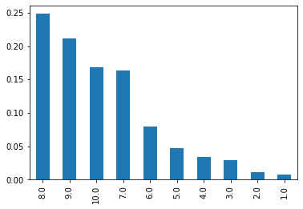

```python
# Starting with the 'Overall Rating' metric provided by the viewers:

df_details['Overall Rating'].value_counts(normalize=True).plot.bar()
```

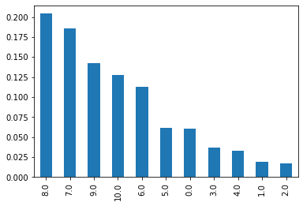

```python
df_details['Story Rating'].value_counts(normalize=True).plot.bar()
```

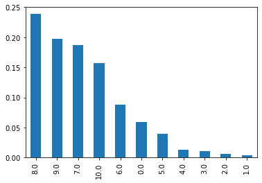

```python
df_details['Animation Rating'].value_counts(normalize=True).plot.bar()
```

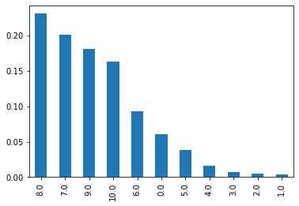

```python
df_details['Sound Rating'].value_counts(normalize=True).plot.bar()
```

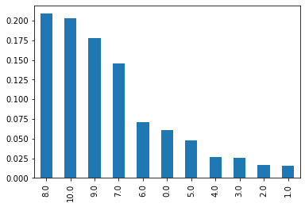

```python
df_details['Character Rating'].value_counts(normalize=True).plot.bar()
```

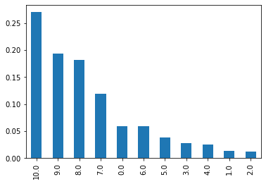

```python
df_details['Enjoyment Rating'].value_counts(normalize=True).plot.bar()
```

Aside from 'Enjoyment Rating', most users really rated at 8 the most frequently. 0 Ratings were actually more common than I thought as well, sometimes showing up as fifth or sixth most common rating.

```python
# Creating a User-Item Count Matrix:

# Shifting the IDs by 1
df_details['Ranking'] = df_details['Ranking'] -1
df_details['Username'] = df_details['Username'] -1
```

[output not shown]

[output cut: 20 more lines]

[output not shown]

```python
Anime_index = df_details[['Ranking','Anime Title']].drop_duplicates()
Anime_index = Anime_index.set_index('Ranking')
Anime_index.sort_values('Ranking').head(55)
```

| Ranking | Anime Title |
| --- | --- |
| 0 | Fullmetal Alchemist: Brotherhood |
| 1 | Steins;Gate |
| 2 | Gintama° |
| 3 | Hunter x Hunter (2011) |
| 4 | Ginga Eiyuu Densetsu |
| 5 | Gintama' |
| 6 | Shingeki no Kyojin Season 3 Part 2 |
| 7 | Gintama': Enchousen |
| 8 | 3-gatsu no Lion 2nd Season |
| 9 | Koe no Katachi |
| 10 | Kimi no Na wa. |
| 11 | Gintama. |
| 12 | Gintama |
| 13 | Gintama Movie 2: Kanketsu-hen - Yorozuya yo Ei... |
| 14 | Clannad: After Story |
| 15 | Owarimonogatari 2nd Season |
| 16 | Code Geass: Hangyaku no Lelouch R2 |
| 17 | Haikyuu!!: Karasuno Koukou vs. Shiratorizawa G... |
| 18 | Mob Psycho 100 II |
| 19 | Gintama.: Shirogane no Tamashii-hen - Kouhan-sen |
| 20 | Sen to Chihiro no Kamikakushi |
| 21 | Kizumonogatari III: Reiketsu-hen |
| 22 | Gintama.: Shirogane no Tamashii-hen |
| 23 | Cowboy Bebop |
| 24 | Kaguya-sama wa Kokurasetai?: Tensai-tachi no R... |
| 25 | Shouwa Genroku Rakugo Shinjuu: Sukeroku Futata... |
| 26 | Made in Abyss Movie 3: Fukaki Tamashii no Reimei |
| 27 | Monogatari Series: Second Season |
| 28 | Haikyuu!! Second Season |
| 29 | Mushishi Zoku Shou 2nd Season |
| 30 | Shigatsu wa Kimi no Uso |
| 31 | Made in Abyss |
| 32 | Fate/stay night Movie: Heaven's Feel - III. Sp... |
| 33 | Hajime no Ippo |
| 34 | Monster |
| 35 | Mononoke Hime |
| 36 | Mushishi Zoku Shou |
| 37 | Rurouni Kenshin: Meiji Kenkaku Romantan - Tsui... |
| 38 | Vinland Saga |
| 39 | Code Geass: Hangyaku no Lelouch |
| 40 | Tian Guan Ci Fu |
| 41 | Seishun Buta Yarou wa Yumemiru Shoujo no Yume ... |
| 42 | Great Teacher Onizuka |
| 43 | Mushishi |
| 44 | Hajime no Ippo: New Challenger |
| 45 | Natsume Yuujinchou Shi |
| 46 | Ashita no Joe 2 |
| 47 | Howl no Ugoku Shiro |
| 48 | Kimetsu no Yaiba |
| 49 | Tengen Toppa Gurren Lagann |
| 50 | Ookami Kodomo no Ame to Yuki |
| 51 | Suzumiya Haruhi no Shoushitsu |
| 52 | Natsume Yuujinchou Roku |
| 53 | Yakusoku no Neverland |
| 54 | Mushishi Zoku Shou: Suzu no Shizuku |

```python
# Setup for Model 1: Collaborative Filtering using User data (ratings):

# Taking a look at the User-Item Matrix:

UserItemMatrix = pd.pivot_table(df_details, values = 'Score', index = ['Ranking'], columns = ['Username'])
print(UserItemMatrix.values.shape)
```

```
(4316, 2550)
```

```python
UserItemMatrix
```

| Username Ranking | --Sunclaudius | -Alice- | -Anokata | -FlameHaze- | -Haoto- | -Heika | -HippySnob- | -Mahesvara | -Naami- | -Remix- | -SeRg- | -ShadowClaw- | 011253 | 0207xander | 032 | 0Seru0 | 0w0 | 19wongs4 | 1nfiniteXcaliber | 2000 | 27lily | 2Daggers | 2LongDidntReview | 2gud2btru | 2life | 33Nanoseconds | 3N437 | 3ricTheRed | 3xTripple | … |
| --- | --- | --- | --- | --- | --- | --- | --- | --- | --- | --- | --- | --- | --- | --- | --- | --- | --- | --- | --- | --- | --- | --- | --- | --- | --- | --- | --- | --- | --- | --- |
| 0 | NaN | NaN | NaN | NaN | NaN | NaN | NaN | NaN | NaN | NaN | NaN | NaN | NaN | NaN | NaN | NaN | NaN | NaN | NaN | NaN | NaN | NaN | NaN | NaN | NaN | NaN | NaN | NaN | NaN | … |
| 1 | NaN | NaN | NaN | NaN | NaN | NaN | NaN | NaN | NaN | NaN | NaN | NaN | NaN | NaN | NaN | NaN | NaN | NaN | NaN | NaN | NaN | NaN | NaN | NaN | NaN | NaN | NaN | NaN | NaN | … |
| 2 | NaN | NaN | NaN | NaN | NaN | NaN | NaN | NaN | NaN | NaN | NaN | NaN | NaN | NaN | NaN | NaN | NaN | NaN | NaN | NaN | NaN | NaN | NaN | NaN | NaN | NaN | NaN | NaN | NaN | … |
| 3 | NaN | NaN | NaN | NaN | NaN | NaN | NaN | NaN | NaN | NaN | NaN | NaN | NaN | NaN | NaN | NaN | NaN | NaN | NaN | NaN | NaN | NaN | NaN | NaN | NaN | NaN | NaN | NaN | NaN | … |
| 4 | NaN | NaN | NaN | NaN | NaN | NaN | NaN | NaN | NaN | NaN | NaN | NaN | NaN | NaN | NaN | NaN | NaN | NaN | NaN | NaN | NaN | NaN | NaN | NaN | NaN | NaN | NaN | NaN | NaN | … |
| ... | ... | ... | ... | ... | ... | ... | ... | ... | ... | ... | ... | ... | ... | ... | ... | ... | ... | ... | ... | ... | ... | ... | ... | ... | ... | ... | ... | ... | ... | … |
| 4993 | NaN | NaN | NaN | NaN | NaN | NaN | NaN | NaN | NaN | NaN | NaN | NaN | NaN | NaN | NaN | NaN | NaN | NaN | NaN | NaN | NaN | NaN | NaN | NaN | NaN | NaN | NaN | NaN | NaN | … |
| 4995 | NaN | NaN | NaN | NaN | NaN | NaN | NaN | NaN | NaN | NaN | NaN | NaN | NaN | NaN | NaN | NaN | NaN | NaN | NaN | NaN | NaN | NaN | NaN | NaN | NaN | NaN | NaN | NaN | NaN | … |
| 4998 | NaN | NaN | NaN | NaN | NaN | NaN | NaN | NaN | NaN | NaN | NaN | NaN | NaN | NaN | NaN | NaN | NaN | NaN | NaN | NaN | NaN | NaN | NaN | NaN | NaN | NaN | NaN | NaN | NaN | … |
| 4999 | NaN | NaN | NaN | NaN | NaN | NaN | NaN | NaN | NaN | NaN | NaN | NaN | NaN | NaN | NaN | NaN | NaN | NaN | NaN | NaN | NaN | NaN | NaN | NaN | NaN | NaN | NaN | NaN | NaN | … |
| 5000 | NaN | NaN | NaN | NaN | NaN | NaN | NaN | NaN | NaN | NaN | NaN | NaN | NaN | NaN | NaN | NaN | NaN | NaN | NaN | NaN | NaN | NaN | NaN | NaN | NaN | NaN | NaN | NaN | NaN | … |

4316 rows × 2550 columns

I can already see how this would not be a good approach, but it could be used as a baseline... There are just too many missing values for this dataset. For a content-based method, I will need to get most similar titles given a searched title, and start by getting 'similarity scores'.

```python
from sklearn.neighbors import NearestNeighbors
```

```python
# Let's try filling the null values with zeros, just to get a baseline:
dummyMatrix1 = UserItemMatrix.fillna(0)
```

```python
knn = NearestNeighbors(metric='cosine', n_neighbors=10)
knn.fit(dummyMatrix1)
distances, indices = knn.kneighbors(dummyMatrix1)
```

```python
distances[:2]
```

```
array([[0., 0., 1., 1., 1., 1., 1., 1., 1., 1.],
       [0., 0., 0., 0., 0., 0., 0., 0., 0., 0.]])
```

```python
indices[:10]
```

```
array([[   0, 1462, 2877, 2881, 2880, 2879, 2878, 2875, 2876, 2872],
       [ 459,  872,  734, 4144, 1286,  966,  995,  718,  193, 2045],
       [   2,    7, 2876, 2874, 2881, 2880, 2879, 2878, 2877, 2883],
       [   3, 2876, 2874, 2881, 2880, 2879, 2878, 2877, 2883, 2872],
       [3688,    4, 2216, 2876, 2874, 2879, 2878, 2877, 2881, 2875],
       [   5, 2876, 2874, 2881, 2880, 2879, 2878, 2877, 2883, 2872],
       [1443,    6,  137, 2874, 2880, 2879, 2878, 2877, 2876, 2882],
       [   2,    7, 2876, 2874, 2881, 2880, 2879, 2878, 2877, 2883],
       [   8, 2875, 2881, 2880, 2879, 2878, 2877, 2876, 2883, 2872],
       [   9,  727,  519, 3022, 2176, 1109,  579, 3462,  768, 3033]])
```

```python
indices_near_Animes = indices[0]
Animes_indices = Anime_index.loc[indices_near_Animes]['Anime Title'].tolist()
print(indices_near_Animes, Animes_indices)
```

```
[   0 1462 2877 2881 2880 2879 2878 2875 2876 2872] ['Fullmetal Alchemist: Brotherhood', 'Fushigi no Umi no Nadia', 'Nanatsu no Taizai: Seisen no Shirushi', 'Owari no Seraph: Kyuuketsuki Shahar', 'Onmyou Taisenki', 'One Piece Recap', 'One Piece Film: Gold Episode 0 - 711 ver.', 'Machine-Doll wa Kizu…
```

hmmm... I don't see Hunter x Hunter, or the other top 5 recommended titles by other users.. Let's check a few others:

```python
def rec1_Animes(m_item):
    print('Titles similar to ', Anime_index.loc[m_item]['Anime Title'])
    indices_near_Animes = indices[m_item]
    Animes_indices = Anime_index.loc[indices_near_Animes]['Anime Title']

    for i in Animes_indices:
        print(i)
    print()
    print('___________________________________________________')

rec1_Animes(3) # Hunter x Hunter
rec1_Animes(16) # Code Geass
rec1_Animes(23) # Cowboy Bebop
rec1_Animes(27) # Monogatari
rec1_Animes(47) # Howl's Moving Castle
```

```
Titles similar to  Hunter x Hunter (2011)
Hunter x Hunter (2011)
Mouretsu Pirates
Lupin III: $1 Money Wars
Owari no Seraph: Kyuuketsuki Shahar
Onmyou Taisenki
One Piece Recap
One Piece Film: Gold Episode 0 - 711 ver.
Nanatsu no Taizai: Seisen no Shirushi
Ranma ½: Battle ga Ippai 29-nin no Korinai Yatsura
Koukyoushihen Eureka Seven: Pocket ga Niji de Ippai

___________________________________________________
Titles similar to  Code Geass: Hangyaku no Lelouch R2
Code Geass: Hangyaku no Lelouch R2
Nanatsu no Taizai: Seisen no Shirushi
Machine-Doll wa Kizutsukanai
Qin Shi Ming Yue: Wanli Changcheng
Owari no Seraph: Kyuuketsuki Shahar
Onmyou Taisenki
One Piece Recap
One Piece Film: Gold Episode 0 - 711 ver.
Ranma ½: Nettou Uta Gassen
Koukyoushihen Eureka Seven: Pocket ga Niji de Ippai

___________________________________________________
Titles similar to  Cowboy Bebop
Uchuu Senkan Yamato III
JoJo no Kimyou na Bouken (TV)
Yes! Precure 5
The iDOLM@STER Movie: Kagayaki no Mukougawa e!
Hibike! Euphonium
Koyomimonogatari
Goblin Slayer
Gallery Fake
Sukitte Ii na yo.: Dareka ga
Kimi ni Todoke 2nd Season: Minitodo Gekijou

___________________________________________________
Titles similar to  Monogatari Series: Second Season
```

[output cut: 10 more lines]

```

___________________________________________________
Titles similar to  Howl no Ugoku Shiro
Howl no Ugoku Shiro
Nanatsu no Taizai: Seisen no Shirushi
Machine-Doll wa Kizutsukanai
Owari no Seraph: Kyuuketsuki Shahar
Onmyou Taisenki
One Piece Recap
One Piece Film: Gold Episode 0 - 711 ver.
Ranma ½: Battle ga Ippai 29-nin no Korinai Yatsura
Mouretsu Pirates
Koukyoushihen Eureka Seven: Pocket ga Niji de Ippai

___________________________________________________
```

Let's try a Content-Based Method w/ the Nearest Neighbor algorithm:

```python
# Since I want to be able to use the 'Rating' column (PG-13, R, etc..), I will need to encode it, assigning something like G = 0, PG-13 = 1, R = 2..
# The 'Episodes' column also has some random values filled in with "Unknown"
# The 'Ratings' column also has some random values filled in with "None"
```

```python
# Lets look at some of the categorical features:
Rating_feature = pd.pivot_table(data=df_details,index=['Rating'])
Rating_feature
```

| Rating | Animation Rating | Character Rating | Enjoyment Rating | Favorites | Members | No. of Recommendations | Overall Rating | Popularity | Ranking | Score | Sound Rating | Story Rating |
| --- | --- | --- | --- | --- | --- | --- | --- | --- | --- | --- | --- | --- |
| G - All Ages | 7.555556 | 7.557870 | 7.898148 | 46.333487 | 6430.228176 | 4.278195 | 8.043981 | 9244.170901 | 6653.206005 | 6.272527 | 7.555556 | 7.215278 |
| None | 6.696970 | 6.575758 | 6.606061 | 88.420635 | 17549.317460 | 3.800000 | 7.696970 | 6811.650794 | 5798.880952 | 6.504921 | 6.939394 | 6.272727 |
| PG - Children | 7.717300 | 7.641350 | 8.177215 | 129.605031 | 15202.549686 | 4.864407 | 8.130802 | 7350.642767 | 5499.767296 | 6.569182 | 7.928270 | 7.337553 |
| PG-13 - Teens 13 or older | 7.303443 | 7.189557 | 7.396141 | 834.557794 | 63958.007236 | 11.354589 | 7.629588 | 4848.013691 | 4394.941522 | 6.864931 | 7.262580 | 6.667045 |
| R - 17+ (violence & profanity) | 7.356037 | 6.911765 | 7.314241 | 2214.526006 | 133456.097154 | 16.614085 | 7.472136 | 3410.177625 | 3629.415113 | 7.087370 | 7.363777 | 6.648607 |
| R+ - Mild Nudity | 7.747692 | 7.412308 | 7.803077 | 558.636829 | 64644.324808 | 12.475248 | 7.692308 | 4474.342711 | 5521.898977 | 6.564923 | 7.492308 | 6.806154 |

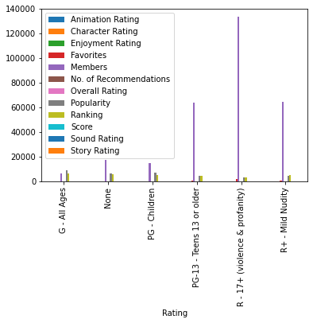

```python
Rating_feature.plot(kind='bar')
```

```python
Genres_feature = pd.pivot_table(data=df_details,index=['Genres'])
Genres_feature
```

| Genres | Animation Rating | Character Rating | Enjoyment Rating | Favorites | Members | No. of Recommendations | Overall Rating | Popularity | Ranking | Score | Sound Rating | Story Rating |
| --- | --- | --- | --- | --- | --- | --- | --- | --- | --- | --- | --- | --- |
| Action | 8.0 | 6.8 | 7.2 | 51.189189 | 1.939224e+04 | 7.0 | 6.0 | 7438.135135 | 7227.081081 | 6.108919 | 7.4 | 6.4 |
| Action, Adventure | 8.0 | 5.5 | 5.5 | 287.000000 | 4.262586e+04 | 19.0 | 6.0 | 7049.285714 | 6620.714286 | 6.262857 | 7.5 | 4.5 |
| Action, Adventure, Cars, Comedy, Kids, Police | NaN | NaN | NaN | 1.000000 | 3.360000e+02 | NaN | NaN | 12833.000000 | 9316.000000 | 5.560000 | NaN | NaN |
| Action, Adventure, Cars, Comedy, Sci-Fi, Shounen | 10.0 | 10.0 | 10.0 | 16.500000 | 6.249500e+03 | NaN | 10.0 | 5957.000000 | 4852.500000 | 6.700000 | 10.0 | 10.0 |
| Action, Adventure, Cars, Sci-Fi | 7.0 | 6.0 | 7.0 | 27.000000 | 1.626500e+04 | NaN | 7.0 | 3889.000000 | 4640.000000 | 6.750000 | 6.0 | 8.0 |
| ... | ... | ... | ... | ... | ... | ... | ... | ... | ... | ... | ... | ... |
| Supernatural, Shounen | 0.0 | 0.0 | 0.0 | 75.500000 | 3.730000e+04 | 1.0 | 7.0 | 2909.500000 | 4083.000000 | 6.920000 | 0.0 | 0.0 |
| Supernatural, Vampire | NaN | NaN | NaN | 13.000000 | 6.599000e+03 | NaN | NaN | 5647.000000 | 6192.000000 | 6.430000 | NaN | NaN |
| Thriller, Mystery, Sci-Fi | NaN | NaN | NaN | 6.000000 | 5.152000e+03 | NaN | NaN | 6209.000000 | 5721.000000 | 6.520000 | NaN | NaN |
| Thriller, Sci-Fi | 8.0 | 8.0 | 8.0 | 139909.000000 | 1.636151e+06 | 104.0 | 8.0 | 8.000000 | 1.000000 | 9.120000 | 8.0 | 8.0 |
| Vampire | 10.0 | 10.0 | 10.0 | 2271.000000 | 3.444060e+05 | 2.0 | 10.0 | 348.000000 | 144.000000 | 8.410000 | 10.0 | 10.0 |

4070 rows × 12 columns

Woah, over 4k combinations of Genre.... maybe I can transform this column to just take the first listed Genre for each row.

```python
#df_details.loc[df_details.Genres == ', ', 'Genres'] = df_details.Genres.str.split().str.get(0)
#df_details.head()

df_details['genre1'] = df_details['Genres']
df_details['genre1'] = df_details.Genres.str.split(', ').str.get(0)
df_details.head()
```

|  | Anime Title | Episodes | Aired | Producers | Licensors | Studios | Source | Genres | Duration | Rating | Score | Ranking | Popularity | Members | Favorites | Summary | Username | Overall Rating | Story Rating | Animation Rating | Sound Rating | Character Rating | Enjoyment Rating | Review | Recommended Title | No. of Recommendations | genre1 |
| --- | --- | --- | --- | --- | --- | --- | --- | --- | --- | --- | --- | --- | --- | --- | --- | --- | --- | --- | --- | --- | --- | --- | --- | --- | --- | --- | --- |
| 0 | Fullmetal Alchemist: Brotherhood | 64 | Apr 5, 2009 to Jul 4, 2010 | Aniplex, Square Enix, Mainichi Broadcasting Sy... | Funimation, Aniplex of America | Bones | Manga | Action, Military, Adventure, Comedy, Drama, Ma... | 24 min. per ep. | R - 17+ (violence & profanity) | 9.22 | 0 | 4 | 2025613 | 167812 | "In order for something to be obtained, someth... | tazillo | 10.0 | 10.0 | 9.0 | 9.0 | 10.0 | 10.0 | First of all, I have seen the original FMA and... | Hunter x Hunter (2011) | 87.0 | Action |
| 1 | Steins;Gate | 24 | Apr 6, 2011 to Sep 14, 2011 | Frontier Works, Media Factory, Movic, AT-X, Ka... | Funimation | White Fox | Visual novel | Thriller, Sci-Fi | 24 min. per ep. | PG-13 - Teens 13 or older | 9.12 | 1 | 8 | 1636151 | 139909 | The self-proclaimed mad scientist Rintarou Oka... | Archaeon | 8.0 | 8.0 | 8.0 | 8.0 | 8.0 | 8.0 | "People assume that time is a strict progressi... | Boku dake ga Inai Machi | 104.0 | Thriller |
| 2 | Gintama° | 51 | Apr 8, 2015 to Mar 30, 2016 | TV Tokyo, Aniplex, Dentsu | Funimation, Crunchyroll | Bandai Namco Pictures | Manga | Action, Comedy, Historical, Parody, Samurai, S... | 24 min. per ep. | PG-13 - Teens 13 or older | 9.11 | 2 | 330 | 363879 | 10353 | Gintoki, Shinpachi, and Kagura return as the f... | Tyrel | 10.0 | 10.0 | 9.0 | 10.0 | 10.0 | 10.0 | Have you ever wanted to laugh so hard that it ... | SKET Dance | 3.0 | Action |
| 3 | Hunter x Hunter (2011) | 148 | Oct 2, 2011 to Sep 24, 2014 | VAP, Nippon Television Network, Shueisha | Viz Media | Madhouse | Manga | Action, Adventure, Fantasy, Shounen, Super Power | 23 min. per ep. | PG-13 - Teens 13 or older | 9.11 | 3 | 14 | 1459320 | 130492 | Hunter x Hunter is set in a world where Hunter... | Cresherhsm | 10.0 | 10.0 | 9.0 | 8.0 | 10.0 | 10.0 | The lack of popularity surrounding Hunter x Hu... | Fullmetal Alchemist: Brotherhood | 87.0 | Action |
| 4 | Ginga Eiyuu Densetsu | 110 | Jan 8, 1988 to Mar 17, 1997 | Kitty Films, K-Factory | Sentai Filmworks | Artland, Magic Bus | Novel | Military, Sci-Fi, Space, Drama | 26 min. per ep. | R - 17+ (violence & profanity) | 9.10 | 4 | 629 | 212162 | 13100 | The 150-year-long stalemate between the two in... | santetjan | 10.0 | 10.0 | 8.0 | 10.0 | 9.0 | 10.0 | This series is overrated on this site. That is... | Code Geass: Hangyaku no Lelouch | 20.0 | Military |

```python
Genres_feature = pd.pivot_table(data=df_details,index=['genre1'])
Genres_feature
```

| genre1 | Animation Rating | Character Rating | Enjoyment Rating | Favorites | Members | No. of Recommendations | Overall Rating | Popularity | Ranking | Score | Sound Rating | Story Rating |
| --- | --- | --- | --- | --- | --- | --- | --- | --- | --- | --- | --- | --- |
| Action | 7.389651 | 7.016209 | 7.354738 | 1156.053160 | 79954.311507 | 12.320433 | 7.460100 | 4810.618476 | 4427.477796 | 6.856454 | 7.334788 | 6.657107 |
| Adventure | 7.691244 | 7.518433 | 7.847926 | 321.724070 | 30785.631115 | 7.248322 | 7.882488 | 6409.545010 | 4736.122309 | 6.775352 | 7.707373 | 7.244240 |
| Cars | 7.500000 | 8.250000 | 8.750000 | 42.312500 | 10115.750000 | 5.000000 | 8.250000 | 7649.625000 | 5483.687500 | 6.563750 | 7.750000 | 7.500000 |
| Comedy | 7.188389 | 7.440758 | 7.614929 | 443.645823 | 46982.438237 | 10.730769 | 7.747630 | 5435.587391 | 4957.548437 | 6.716074 | 7.223934 | 6.652844 |
| Dementia | 8.285714 | 6.857143 | 7.000000 | 397.338028 | 21873.563380 | 14.800000 | 7.571429 | 9725.661972 | 8159.788732 | 5.876338 | 7.857143 | 7.285714 |
| Demons | 7.090909 | 7.636364 | 7.909091 | 567.478261 | 42297.565217 | 7.666667 | 7.727273 | 5305.782609 | 4872.434783 | 6.703478 | 7.363636 | 7.000000 |
| Drama | 7.510638 | 7.412766 | 7.531915 | 852.595699 | 54827.705376 | 10.376147 | 8.059574 | 5806.987097 | 4574.367742 | 6.830645 | 7.395745 | 7.285106 |
| Ecchi | 7.233333 | 6.600000 | 7.166667 | 332.344828 | 55852.758621 | 4.333333 | 7.200000 | 4543.732759 | 6286.146552 | 6.386379 | 6.866667 | 5.766667 |
| Fantasy | 7.666667 | 7.030303 | 7.469697 | 142.848921 | 19717.543165 | 7.636364 | 7.833333 | 7480.514388 | 6272.212230 | 6.375935 | 7.363636 | 6.742424 |
| Game | 7.155556 | 7.333333 | 7.666667 | 849.500000 | 65510.325397 | 14.476190 | 7.955556 | 6642.158730 | 5625.492063 | 6.550238 | 7.200000 | 6.822222 |
| Harem | 7.590909 | 6.803030 | 7.363636 | 691.663551 | 126704.663551 | 14.333333 | 7.000000 | 2588.289720 | 4541.065421 | 6.792430 | 6.939394 | 6.212121 |
| Historical | 6.916667 | 7.125000 | 7.333333 | 41.450549 | 8733.406593 | 4.800000 | 7.875000 | 8309.428571 | 6157.274725 | 6.414725 | 7.083333 | 7.083333 |
| Horror | 8.833333 | 7.833333 | 8.250000 | 300.930233 | 39422.186047 | 28.333333 | 8.000000 | 5984.627907 | 6463.023256 | 6.337674 | 8.166667 | 7.500000 |
| Josei | 9.000000 | 9.500000 | 9.500000 | 2820.000000 | 216249.000000 | 34.000000 | 9.500000 | 1138.000000 | 337.500000 | 8.215000 | 9.500000 | 9.500000 |
| Kids | 7.652174 | 6.391304 | 7.391304 | 12.993197 | 2390.054422 | 8.666667 | 7.652174 | 10413.877551 | 6951.292517 | 6.204014 | 7.130435 | 6.956522 |
| Magic | 7.818182 | 7.272727 | 7.545455 | 24.395349 | 10250.360465 | 1.250000 | 7.727273 | 7326.116279 | 6284.197674 | 6.365116 | 7.590909 | 7.000000 |
| Martial Arts | 5.333333 | 5.666667 | 6.000000 | 85.666667 | 28275.000000 | 2.000000 | 8.333333 | 5389.000000 | 2526.666667 | 7.276667 | 5.666667 | 6.000000 |
| Mecha | 8.166667 | 8.111111 | 8.055556 | 8.153846 | 4197.692308 | 1.000000 | 8.000000 | 8046.338462 | 6799.753846 | 6.233385 | 7.888889 | 8.055556 |
| Military | 7.609756 | 7.829268 | 8.024390 | 359.513158 | 31138.934211 | 6.466667 | 8.146341 | 5208.618421 | 4205.144737 | 6.921974 | 7.853659 | 7.707317 |
| Music | 7.231343 | 6.843284 | 7.485075 | 126.591716 | 9454.213018 | 8.162791 | 8.014925 | 9464.983728 | 6652.363905 | 6.263669 | 7.694030 | 6.231343 |
| Mystery | 7.684783 | 7.304348 | 7.543478 | 2318.096154 | 118706.782051 | 24.636364 | 7.826087 | 4114.532051 | 3630.698718 | 7.092564 | 7.467391 | 7.043478 |
| No genres have | NaN | NaN | NaN | 2.250000 | 1189.000000 | NaN | NaN | 10812.125000 | 9083.000000 | 5.643750 | NaN | NaN |
| Parody | 5.727273 | 7.181818 | 7.636364 | 13.020408 | 8204.061224 | 1.000000 | 7.727273 | 7184.775510 | 6604.469388 | 6.279388 | 6.818182 | 6.454545 |
| Police | 7.500000 | 8.750000 | 7.000000 | 17.500000 | 11090.000000 | NaN | 7.000000 | 4629.666667 | 3138.166667 | 7.118333 | 7.250000 | 5.750000 |
| Psychological | 7.687500 | 6.750000 | 7.250000 | 4488.629630 | 161784.777778 | 31.833333 | 7.187500 | 4432.111111 | 4523.185185 | 6.883333 | 7.750000 | 6.875000 |
| Romance | 7.146341 | 6.512195 | 6.682927 | 1126.909910 | 54443.747748 | 15.692308 | 7.512195 | 5525.747748 | 5567.387387 | 6.576937 | 7.073171 | 6.365854 |
| Samurai | 8.000000 | 6.000000 | 7.000000 | 101.000000 | 43347.000000 | 1.000000 | 6.000000 | 2350.000000 | 1374.000000 | 7.570000 | 7.000000 | 5.000000 |
| School | 8.111111 | 8.777778 | 8.888889 | 39.730769 | 19671.500000 | 3.000000 | 8.555556 | 5660.500000 | 5115.576923 | 6.674231 | 7.555556 | 8.222222 |
| Sci-Fi | 7.349315 | 7.089041 | 7.321918 | 537.371901 | 51425.024793 | 9.032787 | 7.410959 | 5773.066116 | 5158.352617 | 6.667741 | 7.267123 | 6.493151 |
| Seinen | 5.333333 | 3.666667 | 4.000000 | 107.333333 | 42972.333333 | 2.000000 | 6.333333 | 3030.833333 | 5384.166667 | 6.536667 | 5.333333 | 3.666667 |
| Shoujo | 6.000000 | 9.000000 | 4.000000 | 17.000000 | 9779.714286 | NaN | 4.000000 | 5522.000000 | 8405.714286 | 5.782857 | 6.000000 | 4.000000 |
| Shounen | 5.833333 | 8.000000 | 7.833333 | 60.466667 | 16735.200000 | 3.000000 | 8.166667 | 6400.333333 | 4640.066667 | 6.782667 | 6.166667 | 6.500000 |
| Shounen Ai | NaN | NaN | NaN | 100.000000 | 8605.000000 | NaN | NaN | 8174.500000 | 7601.500000 | 6.110000 | NaN | NaN |
| Slice of Life | 7.347682 | 7.486755 | 7.619205 | 1006.136964 | 69799.255776 | 14.431373 | 8.033113 | 5358.295380 | 4527.079208 | 6.838548 | 7.327815 | 6.804636 |
| Space | 8.000000 | 8.000000 | 8.250000 | 83.700000 | 10839.000000 | 3.000000 | 8.250000 | 8055.500000 | 6892.150000 | 6.245500 | 8.250000 | 7.500000 |
| Sports | 7.026316 | 7.026316 | 7.105263 | 127.969697 | 19819.888889 | 8.500000 | 7.631579 | 6706.969697 | 5231.363636 | 6.646768 | 7.184211 | 6.763158 |
| Super Power | 7.500000 | 6.750000 | 7.500000 | 190.250000 | 46005.625000 | 1.000000 | 7.250000 | 5230.500000 | 4965.000000 | 6.671250 | 7.000000 | 5.000000 |
| Supernatural | 7.000000 | 7.090909 | 6.818182 | 52.736842 | 18795.526316 | 8.000000 | 8.000000 | 6299.605263 | 6143.157895 | 6.411579 | 7.090909 | 6.181818 |
| Thriller | 8.000000 | 8.000000 | 8.000000 | 69957.500000 | 820651.500000 | 104.000000 | 8.000000 | 3108.500000 | 2861.000000 | 7.820000 | 8.000000 | 8.000000 |
| Vampire | 10.000000 | 10.000000 | 10.000000 | 2271.000000 | 344406.000000 | 2.000000 | 10.000000 | 348.000000 | 144.000000 | 8.410000 | 10.000000 | 10.000000 |

```python
Genres_feature.info()
# 40 genres is much more manageable!
```

```
<class 'pandas.core.frame.DataFrame'>
Index: 40 entries, Action to Vampire
Data columns (total 12 columns):
 #   Column                  Non-Null Count  Dtype
---  ------                  --------------  -----
 0   Animation Rating        38 non-null     float64
 1   Character Rating        38 non-null     float64
 2   Enjoyment Rating        38 non-null     float64
 3   Favorites               40 non-null     float64
 4   Members                 40 non-null     float64
 5   No. of Recommendations  36 non-null     float64
 6   Overall Rating          38 non-null     float64
 7   Popularity              40 non-null     float64
 8   Ranking                 40 non-null     float64
 9   Score                   40 non-null     float64
 10  Sound Rating            38 non-null     float64
 11  Story Rating            38 non-null     float64
dtypes: float64(12)
memory usage: 4.1+ KB
```

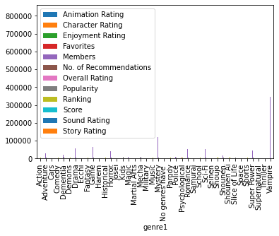

```python
Genres_feature.plot(kind='bar')
# Something is up with the Vampire genre. it looks like it has a lot of Members.
```

```python
df_details['Genres'] = df_details['Genres'].str.split(', ')
dfx = pd.get_dummies(pd.DataFrame(df_details['Genres'].tolist()).stack()).sum(level=0)
df_details = pd.concat([df_details, dfx], axis=1).drop(columns=['Genres'])
df_details.head()
```

|  | Anime Title | Episodes | Aired | Producers | Licensors | Studios | Source | Duration | Rating | Score | Ranking | Popularity | Members | Favorites | Summary | Username | Overall Rating | Story Rating | Animation Rating | Sound Rating | Character Rating | Enjoyment Rating | Review | Recommended Title | No. of Recommendations | genre1 | Action | Adventure | Cars | … |
| --- | --- | --- | --- | --- | --- | --- | --- | --- | --- | --- | --- | --- | --- | --- | --- | --- | --- | --- | --- | --- | --- | --- | --- | --- | --- | --- | --- | --- | --- | --- |
| 0 | Fullmetal Alchemist: Brotherhood | 64 | Apr 5, 2009 to Jul 4, 2010 | Aniplex, Square Enix, Mainichi Broadcasting Sy... | Funimation, Aniplex of America | Bones | Manga | 24 min. per ep. | R - 17+ (violence & profanity) | 9.22 | 0 | 4 | 2025613 | 167812 | "In order for something to be obtained, someth... | tazillo | 10.0 | 10.0 | 9.0 | 9.0 | 10.0 | 10.0 | First of all, I have seen the original FMA and... | Hunter x Hunter (2011) | 87.0 | Action | 1 | 1 | 0 | … |
| 1 | Steins;Gate | 24 | Apr 6, 2011 to Sep 14, 2011 | Frontier Works, Media Factory, Movic, AT-X, Ka... | Funimation | White Fox | Visual novel | 24 min. per ep. | PG-13 - Teens 13 or older | 9.12 | 1 | 8 | 1636151 | 139909 | The self-proclaimed mad scientist Rintarou Oka... | Archaeon | 8.0 | 8.0 | 8.0 | 8.0 | 8.0 | 8.0 | "People assume that time is a strict progressi... | Boku dake ga Inai Machi | 104.0 | Thriller | 0 | 0 | 0 | … |
| 2 | Gintama° | 51 | Apr 8, 2015 to Mar 30, 2016 | TV Tokyo, Aniplex, Dentsu | Funimation, Crunchyroll | Bandai Namco Pictures | Manga | 24 min. per ep. | PG-13 - Teens 13 or older | 9.11 | 2 | 330 | 363879 | 10353 | Gintoki, Shinpachi, and Kagura return as the f... | Tyrel | 10.0 | 10.0 | 9.0 | 10.0 | 10.0 | 10.0 | Have you ever wanted to laugh so hard that it ... | SKET Dance | 3.0 | Action | 1 | 0 | 0 | … |
| 3 | Hunter x Hunter (2011) | 148 | Oct 2, 2011 to Sep 24, 2014 | VAP, Nippon Television Network, Shueisha | Viz Media | Madhouse | Manga | 23 min. per ep. | PG-13 - Teens 13 or older | 9.11 | 3 | 14 | 1459320 | 130492 | Hunter x Hunter is set in a world where Hunter... | Cresherhsm | 10.0 | 10.0 | 9.0 | 8.0 | 10.0 | 10.0 | The lack of popularity surrounding Hunter x Hu... | Fullmetal Alchemist: Brotherhood | 87.0 | Action | 1 | 1 | 0 | … |
| 4 | Ginga Eiyuu Densetsu | 110 | Jan 8, 1988 to Mar 17, 1997 | Kitty Films, K-Factory | Sentai Filmworks | Artland, Magic Bus | Novel | 26 min. per ep. | R - 17+ (violence & profanity) | 9.10 | 4 | 629 | 212162 | 13100 | The 150-year-long stalemate between the two in... | santetjan | 10.0 | 10.0 | 8.0 | 10.0 | 9.0 | 10.0 | This series is overrated on this site. That is... | Code Geass: Hangyaku no Lelouch | 20.0 | Military | 0 | 0 | 0 | … |

```python
Genre_features = ['Action', 'Adventure', 'Cars', 'Comedy', 'Dementia', 'Demons', 'Drama', 'Ecchi', 'Fantasy', 'Game', 'Harem', 'Historical', 'Horror', 'Josei', 'Kids', 'Magic', 'Martial Arts', 'Mecha', 'Military', 'Music', 'Mystery', 'Parody', 'Police', 'Psychological', 'Romance', 'Samurai', 'School', 'Sci-Fi', 'Seinen', 'Shoujo', 'Shounen', 'Shounen Ai', 'Slice of Life', 'Space', 'Sports', 'Super Power', 'Supernatural', 'Thriller', 'Vampire']  # , 'No genres have']
Anime_features = ['Score', 'Popularity',  'Members', 'Favorites', 'Episodes', 'Rating', 'Overall Rating', 'Story Rating', 'Animation Rating', 'Sound Rating', 'Character Rating', 'Enjoyment Rating']  #,'Score', 'Popularity',  'Members', 'Favorites']
Anime_Matrix = df_details[['Ranking']+Anime_features+Genre_features].drop_duplicates().sort_values('Ranking').reset_index()
# Let's try filling the null values with zeros, to see if we can make use of the user ratings (overall, story, character, story, etc..):
Anime_Matrix1 = Anime_Matrix.fillna(0)

# Lets also replace some feature values where text like "None" was used in place of null-values:
Anime_Matrix1['Episodes'] = Anime_Matrix1['Episodes'].replace(['Unknown'], 0)
Anime_Matrix1["Episodes"] = pd.to_numeric(Anime_Matrix1["Episodes"])

# Let's also encode the Rating (R, PG-13):
Anime_Matrix1['Rating'] = Anime_Matrix1['Rating'].map({'None': 0, 'G - All Ages': 1, 'PG - Children': 2, 'PG-13 - Teens 13 or older': 3, 'R - 17+ (violence & profanity)': 4, 'R+ - Mild Nudity': 5})
Anime_Matrix1.head()
```

|  | index | Ranking | Score | Popularity | Members | Favorites | Episodes | Rating | Overall Rating | Story Rating | Animation Rating | Sound Rating | Character Rating | Enjoyment Rating | Action | Adventure | Cars | Comedy | Dementia | Demons | Drama | Ecchi | Fantasy | Game | Harem | Historical | Horror | Josei | Kids | … |
| --- | --- | --- | --- | --- | --- | --- | --- | --- | --- | --- | --- | --- | --- | --- | --- | --- | --- | --- | --- | --- | --- | --- | --- | --- | --- | --- | --- | --- | --- | --- |
| 0 | 0 | 0 | 9.22 | 4 | 2025613 | 167812 | 64 | 4 | 10.0 | 10.0 | 9.0 | 9.0 | 10.0 | 10.0 | 1 | 1 | 0 | 1 | 0 | 0 | 1 | 0 | 1 | 0 | 0 | 0 | 0 | 0 | 0 | … |
| 1 | 1 | 1 | 9.12 | 8 | 1636151 | 139909 | 24 | 3 | 8.0 | 8.0 | 8.0 | 8.0 | 8.0 | 8.0 | 0 | 0 | 0 | 0 | 0 | 0 | 0 | 0 | 0 | 0 | 0 | 0 | 0 | 0 | 0 | … |
| 2 | 2 | 2 | 9.11 | 330 | 363879 | 10353 | 51 | 3 | 10.0 | 10.0 | 9.0 | 10.0 | 10.0 | 10.0 | 1 | 0 | 0 | 1 | 0 | 0 | 0 | 0 | 0 | 0 | 0 | 1 | 0 | 0 | 0 | … |
| 3 | 3 | 3 | 9.11 | 14 | 1459320 | 130492 | 148 | 3 | 10.0 | 10.0 | 9.0 | 8.0 | 10.0 | 10.0 | 1 | 1 | 0 | 0 | 0 | 0 | 0 | 0 | 1 | 0 | 0 | 0 | 0 | 0 | 0 | … |
| 4 | 4 | 4 | 9.10 | 629 | 212162 | 13100 | 110 | 4 | 10.0 | 10.0 | 8.0 | 10.0 | 9.0 | 10.0 | 0 | 0 | 0 | 0 | 0 | 0 | 1 | 0 | 0 | 0 | 0 | 0 | 0 | 0 | 0 | … |

```python
knn = NearestNeighbors(metric = 'jaccard', n_neighbors = 10)
knn.fit(Anime_Matrix1.drop(columns=['Ranking']))
distances, indices = knn.kneighbors(Anime_Matrix1.drop(columns=['Ranking']))
```

```python
rec1_Animes(0) # Full Metal Alchemist
rec1_Animes(3) # Hunter x Hunter
rec1_Animes(16) # Code Geass
rec1_Animes(23) # Cowboy Bebop
rec1_Animes(27) # Monogatari
rec1_Animes(47) # Howl's Moving Castle
```

```
Titles similar to  Fullmetal Alchemist: Brotherhood
Fullmetal Alchemist: Brotherhood
Fullmetal Alchemist: The Sacred Star of Milos
Fullmetal Alchemist
Fairy Tail Movie 2: Dragon Cry
Fairy Tail Movie 1: Houou no Miko
Fullmetal Alchemist: Brotherhood Specials
Fairy Tail x Rave
Digimon Frontier
Fullmetal Alchemist: Reflections
One Piece Film: Z

___________________________________________________
Titles similar to  Hunter x Hunter (2011)
Hunter x Hunter Movie 2: The Last Mission
Hunter x Hunter (2011)
Hunter x Hunter: Greed Island Final
Hunter x Hunter
Hunter x Hunter: Greed Island
One Piece Movie 2: Nejimaki-jima no Daibouken
One Piece: Episode of Luffy - Hand Island no Bouken
One Piece: Glorious Island
Dragon Ball Super Movie: Broly
One Piece Movie 3: Chinjuu-jima no Chopper Oukoku

___________________________________________________
Titles similar to  Code Geass: Hangyaku no Lelouch R2
Code Geass: Hangyaku no Lelouch R2
Code Geass: Fukkatsu no Lelouch
Code Geass: Hangyaku no Lelouch
Soukou Kihei Votoms: Genei-hen
Soukyuu no Fafner: Dead Aggressor - Exodus
Soukyuu no Fafner: Dead Aggressor - The Beyond
Soukyuu no Fafner: Dead Aggressor
Soukyuu no Fafner: Dead Aggressor - Heaven and Earth
Soukyuu no Fafner: Right of Left - Single Program
Soukou Kihei Votoms: Big Battle

___________________________________________________
Titles similar to  Cowboy Bebop
```

[output cut: 23 more lines]

```

___________________________________________________
Titles similar to  Howl no Ugoku Shiro
Howl no Ugoku Shiro
Giniro no Kami no Agito
Fushigi Yuugi: Eikouden
Sirius no Densetsu
Kino no Tabi: The Beautiful World - Byouki no Kuni - For You
Tales of the Abyss
Sekai Meisaku Douwa: Hakuchou no Mizuumi
Neko no Ongaeshi
Chirin no Suzu
Luo Xiao Hei Zhan Ji (Movie)

___________________________________________________
```

Incorporating the genres into the model was actually super important. Before adding these features as separate columns, I was getting very similar recommendations for every title I searched, probably because the model was mostly weighted towards using titles that were popular overall and rated mostly between 7-9 out of 10. In other words, the data that I gave the model was not that different for each title until I included more genre information.

```python
from surprise import Reader
from surprise import Dataset
from surprise.model_selection import cross_validate
from surprise import KNNBasic
from surprise import KNNWithMeans
from surprise import KNNWithZScore
from surprise import KNNBaseline
from surprise import SVD
from surprise import BaselineOnly
from surprise import NMF
from surprise.accuracy import rmse
from surprise import accuracy
from surprise.model_selection import train_test_split

# Want to use RMSE on particular sets of recommedations from each approach. We can use Surprise library...
#from surprise import Reader
#from surprise import Dataset

reader = Reader(rating_scale = (0,10))
data = Dataset.load_from_df(df_details[['Username', 'Ranking', 'Score']], reader)
```

```python
benchmark = []
# Iterate over all algorithms
for algorithm in [SVD(), NMF(), KNNBasic(), KNNWithMeans(), KNNWithZScore(), BaselineOnly()]:
    # Perform cross validation
    results = cross_validate(algorithm, data, measures=['RMSE'], cv=5, verbose=False)

    # Get results & append algorithm name
    tmp = pd.DataFrame.from_dict(results).mean(axis=0)
    tmp = tmp.append(pd.Series([str(algorithm).split(' ')[0].split('.')[-1]], index=['Algorithm']))
    benchmark.append(tmp)
```

[output not shown]

```python
surprise_results = pd.DataFrame(benchmark).set_index('Algorithm').sort_values('test_rmse')
surprise_results
```

| Algorithm | test_rmse | fit_time | test_time |
| --- | --- | --- | --- |
| SVD | 0.612436 | 0.366535 | 0.007280 |
| BaselineOnly | 0.620394 | 0.023570 | 0.007898 |
| KNNWithMeans | 0.763638 | 0.081956 | 0.009369 |
| NMF | 0.763666 | 0.785519 | 0.007666 |
| KNNWithZScore | 0.763697 | 0.126293 | 0.009904 |
| KNNBasic | 0.763792 | 0.070664 | 0.009887 |

```python
# What had the best (lowest) rmse?
# SVD w/ 1.958651 for df_writtenreviews cv=3
# SVD w/ 0.615464 for df_details cv=3
```

It looks like SVD would be the best approach with this dataset. (sounds like this is equivalent to Probabilistic Matrix Factorization).

```python
## Train test split, fit:
trainset, testset = train_test_split(data, test_size=.20)
algo = SVD()
algo.fit(trainset)
predictions = algo.test(testset)

# Accuracy metrics:
accuracy.rmse(predictions)
accuracy.mae(predictions)
```

```
RMSE: 0.6099
MAE:  0.4738
```

```
0.4737855679112243
```

RMSE = .61 is about what was predicted beforehand, so expected..

Let's see if I can predict a rating for a user who did not rate Cowboy Bebop:

```python
uid = str('tazillo')  # Username = tazillo has not rated this title
iid = str(23)  # Item 23 = Cowboy Bebop

# predict rating
pred = algo.predict(uid, iid, r_ui=4, verbose=True)
```

```
user: tazillo    item: 23         r_ui = 4.00   est = 6.77   {'was_impossible': False}
```

```python
# Does this work when there is already a rating? Username = The Llama rated this title: ...
uid = str('The Llama')  # Username = The Llama rated this title as 10
iid = str(23)  # Item 23 = Cowboy Bebop
pred = algo.predict(uid, iid, r_ui=5, verbose=True)
```

```
user: The Llama  item: 23         r_ui = 5.00   est = 6.71   {'was_impossible': False}
```

```python
# Now let's see if creating a DataFrame with all of the predicted ratings provides some improved reccomendations:
```